# **A decade of movement ecology**

Rocío Joo, Simona Picardi, Matthew E. Boone, Thomas A. Clay, Samantha C. Patrick, Vilma Romero and Mathieu Basille

1. An abstract of the manuscript
2. **Data collection and processing** (in this page!)

   2.1. Identification of movement ecology papers

   2.2. Downloading whole manuscripts

   2.3. Extracting the Material and Methods (M&M) sections
3. Data analysis (including figures, tables and links to R codes)
4. Survey about the field of movement ecology applied to movement ecologists

## 2. Data collection and processing

## 2.1. Identification of movement ecology (mov-eco) papers

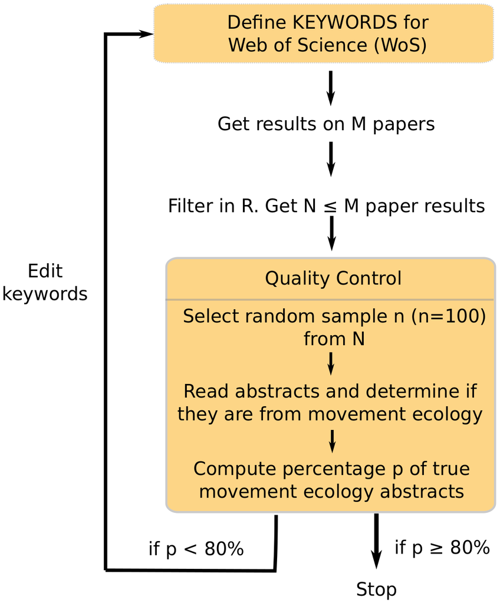

Workflow to identify movement ecology papers.

### What is a movement ecology paper?

We defined mov-eco papers as scientific peer-reviewed papers that studied the voluntary movement of one or more living individuals. This included humans.

### Search keywords

We used Web of Science (WoS) as a search engine for the papers.

- We defined mov-eco papers as scientific peer-reviewed papers that studied the voluntary movement of one or more living individuals. This included humans.
- We used Web of Science (WoS) as a search engine for the papers.
- Very few papers mention “movement ecology” in their abstracts, so we did not use “movement ecology” as a search phrase. After much testing, we came up with the following groups of words:
  - Group 1 - Behavior: behavio
  - Group 2 - Movement: movement, moving, motion, spatiotemporal, kinematics, spatio-temporal
  - Group 3 - Biologging: telemetry, geolocat, biologg, accelerom, gps, geo-locat, bio-logg, reorient, vhf, argos, radar, sonar, gls, vms, animal-borne
  - Group 4 - Individuals: animal, individual, human, person, people, player, wildlife, fishermen

  Paper abstracts had to have words from at least 3 of the groups above to be selected. Also, unless they had words from group 3, they could not contain:
  - Group 5 - Missleading words: cell, DNA, enzyme, strain, neurons, atom, molecule, lymph, cortex, cortic, neurotransmi, patient prosthese, eye, particle, tectonic, counsel, cognit, market, spine, questionnaire, sendentary, insulin

The search on WoS was made over a final selection of 273 journals; made in parallel with keyword tunning.

### Cleaning and filtering results in R

8007 papers were obtained from this.

R Core Team. 2018. R: A Language and Environment for Statistical Computing. Vienna, Austria: R Foundation for Statistical Computing. https://www.R-project.org/.

Fournier, Auriel M. V., Matthew E. Boone, Forrest R. Stevens, and Emilio Bruna. 2019. Refsplitr: Clarivate Analytics Web of Knowledge/Science and Isi Reference Data Tools. https://github.com/embruna/refsplitr.

### Quality control

From the cleaned results, we took a random sample of 100 papers (i.e. with title, abstracts and other features taken from WoS). We then read the abstracts and classified them into “mov-eco” and “not mov-eco”. If the percentage of mov-eco papers (i.e. precision) was lower than 80%, the word criterion used for the search would be improved (e.g. adding more words, editing some, changing the rules for the groups). This is how we came up with the groups introduced above (section 2.1). We obtained 90% of precision. That means that, from the papers that we had, almost all of them were mov-eco papers.

We also wanted to obtain a recall or sensitivity rate to quantify, from the universe of mov-eco papers in the literature, how many we had in our search results. To get an exact number is an impossible task because if we could get the “real” list of mov-eco papers in the literature, we would use it in the first place. Instead, we looked at the list of papers published by the journal Movement Ecology. 69% of them were in our list. An estimated sensitivity of 69% and precision of 90% implies that though we did not get the whole population of mov-eco papers in our set, from the set of papers that we have, there is a very high certainty that they are mov-eco papers.

### Possible biases

We have no reason to believe that our searching criteria has introduced biases to our results. The relatively short list of words is due to the fact that other words we tried were actually reducing our precision, providing us many papers that were not about movement ecology. Of course, it is always possible that we forgot to try an important word. A possible bias could come from WoS: we were not able to get papers that were not in WoS, which depends on WoS agreements.

### Differences with other approaches selecting and analyzing mov-eco papers

- Holyoak et al. 2008: Their goal was to find papers about movement of organisms or gametes, so their definition of movement ecology was somewhat broader than ours. We were inspired by their procedure, and tried the terms that they showed in the paper that would be consistent with our definition of mov-eco. Like us, they used WoS to build their literature dataset. They had a two-step criterion to select the papers. First, they screened the WoS for papers that contained their keywords. Then, they narrowed down the selection by excluding non-ecological journals from their initial results. Two of their coauthors decided on a list of 496 journals. We applied a similar procedure but using a modified set of keywords because we found their criteria to be too broad for our definition, and then two coauthors (R.J. and S.P.) decided on 273 journals. Among the remaining articles, they selected a random sample of 1000 papers for quality control, rating them as relevant or not. Their overall success rate (similar to our precision) was 77%.

  Holyoak, Marcel, Renato Casagrandi, Ran Nathan, Eloy Revilla, and Orr Spiegel. 2008. “Trends and missing parts in the study of movement ecology.” Proceedings of the National Academy of Sciences of the United States of America 105 (49): 19060–5. https://doi.org/10.1073/pnas.0800483105.
- Fraser et al. 2018: They also used the WoS. In “Topics”, they searched for “ecology” and either “movement”, “migrat”, “home range”, “dispersal” or “track”. Their combination of words was too vague in our opinion, and they did not mention any quality control (e.g. precision, recall, specificity, sensitivity) statistic.

  Fraser, K. C., Davies, K. T. A., Davy, C. M., Ford, A. T., Flockhart, D. T. T., & Martins, E. G. (2018). Tracking the Conservation Promise of Movement Ecology. Frontiers in Ecology and Evolution, 6. https://doi.org/10.3389/fevo.2018.00150

## 2.2 Downloading whole manuscripts

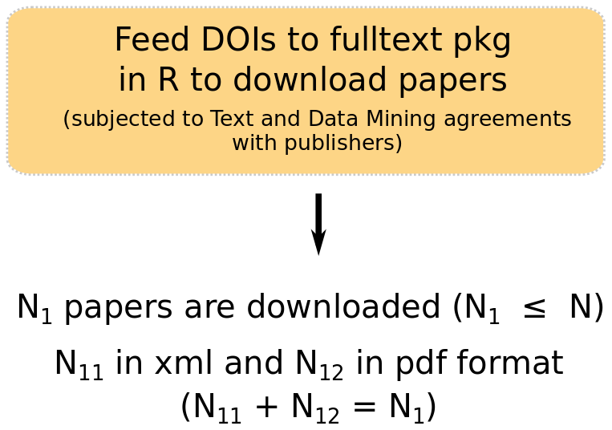

Downloading movement ecology papers.

Chamberlain, Scott. 2019. Fulltext: Full Text of ’Scholarly’ Articles Across Many Data Sources. https://CRAN.R-project.org/package=fulltext.

## 2.3 Extracting the Material and Methods (M&M) sections

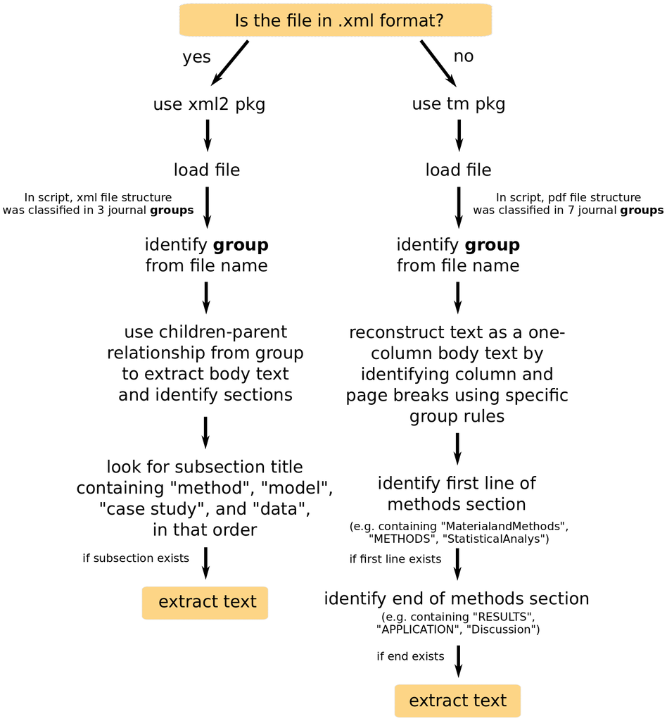

Summary of procedure to extract Material and Methods section from each paper.

Wickham, Hadley, James Hester, and Jeroen Ooms. 2018. Xml2: Parse Xml. https://CRAN.R-project.org/package=xml2.

Feinerer, Ingo, and Kurt Hornik. 2018. Tm: Text Mining Package. https://CRAN.R-project.org/package=tm.